# Active Monitoring Data

## Introduction

This document provides an elementary analysis of data collected from activity monitor devices that record personal movements. Specifically, the data includes the number of steps taken in 5 minute intervals each day during October and November of 2012.

### Loading and preprocessing the data

To begin the analysis, the data was downloaded and was read as a csv file into R:

```r
fileURL<-"https://d396qusza40orc.cloudfront.net/repdata%2Fdata%2Factivity.zip"
file<- "./activFile/actdata.zip"

if (!file.exists("activFile")){
  dir.create("activFile")
}
download.file(fileURL, file)
unzip(file, "activity.csv")

data<-read.csv("activity.csv",header=TRUE)
```

The str() function was applied to the data to get a sense of the data and identify the type of variables:

```r
str(data)
```

```
## 'data.frame':    17568 obs. of  3 variables:
##  $ steps   : int  NA NA NA NA NA NA NA NA NA NA ...
##  $ date    : Factor w/ 61 levels "2012-10-01","2012-10-02",..: 1 1 1 1 1 1 1 1 1 1 ...
##  $ interval: int  0 5 10 15 20 25 30 35 40 45 ...
```

- The steps and interval variable are both integers
- The date variable is a factor variable and needs to processes into a date variable

```r
data$date<-as.Date(data$date, "%Y-%m-%d")
```

### What is mean total number of steps taken per day?

To calculate the number of steps taken per day, a new variable “total” was created and the tapply function was used to sum all the steps by the date:

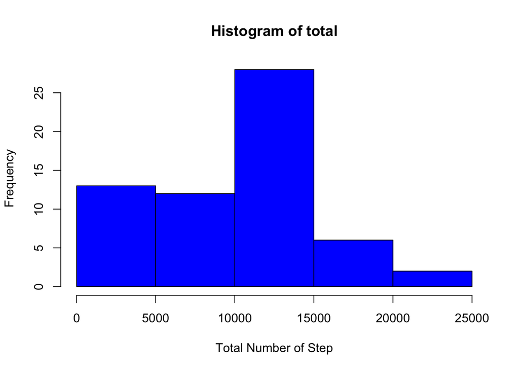

```r
total<-tapply(data$steps, data$date,sum, simplify = TRUE, na.rm=TRUE)

hist(total, xlab="Total Number of Step", col="blue")
```

The mean and median of total:

```r
mean(total)
```

```
## [1] 9354.23
```

```r
median(total)
```

```
## [1] 10395
```

Time series plot of 5-minute interval and the average number of steps take, averaged across all days:

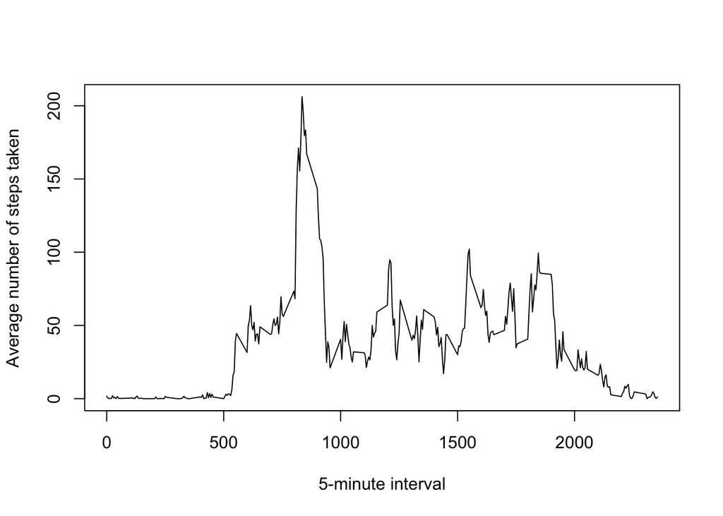

```r
avg<-tapply(data$steps, data$interval,mean,simplify=TRUE, na.rm=TRUE)
intervals<-as.numeric(names(avg))
plot(intervals,avg,type="l", xlab="5-minute interval", ylab="Average number of steps taken")
```

```r
names(which.max(avg))
```

```
## [1] "835"
```

### Imputing missing values

The number of missing values in the steps variable:

```r
sum(is.na(data$steps))
```

```
## [1] 2304
```

The missing values were replaced by the mean of the 5-minute interval:

```r
data$avg<-tapply(data$steps, data$interval,mean,simplify=TRUE, na.rm=TRUE)
data$replace<-data$steps
for(i in 1:length(data$replace)){
  if(is.na(data$replace[i]==TRUE)){
    data$replace[i]<-data$avg[i]
  }
}
```

A new dataset was created with all values filled in:

```r
newData<-data.frame(data$replace,data$date, data$interval)
names(newData)<-c("steps","date","interval")
newtotal<-tapply(newData$steps, newData$date,sum, simplify = TRUE)
```

Histogram of the new total variable:

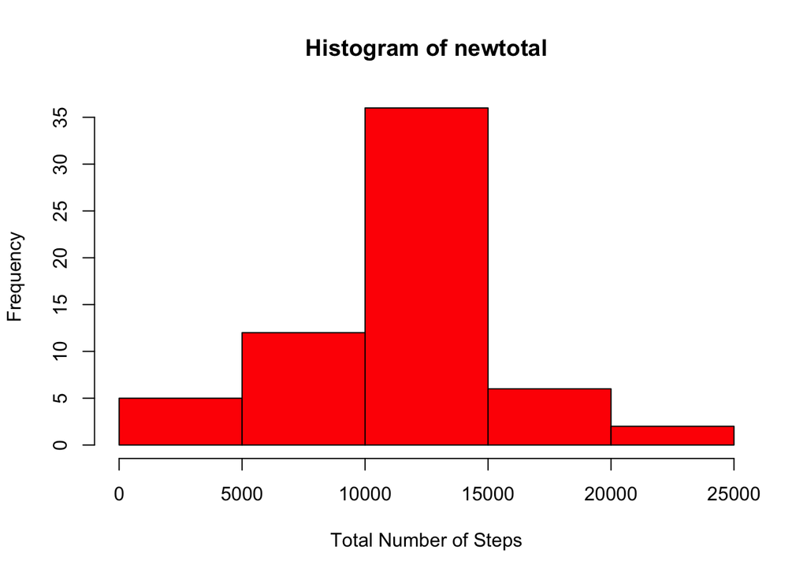

```r
hist(newtotal, xlab="Total Number of Steps", col="red")
```

The mean and median of the new total variable:

```r
mean(newtotal)
```

```
## [1] 10766.19
```

```r
median(newtotal)
```

```
## [1] 10766.19
```

### Differences in activity patterns between weekdays and weekends

A new variable weekend was created to separate the date variables into weekday and weekend:

```r
newData$weekday<-weekdays(newData$date)
wkd<-c("Monday", "Tuesday", "Wednesday", "Thursday", "Friday")
newData$weekend<-factor(newData$weekday %in% wkd,levels=c(FALSE, TRUE),labels=c("weekend","weekday"))

wknd<-newData[newData$weekend=="weekend",]
wkdy<-newData[newData$weekend=="weekday",]
```

Two different sets of data were created to for the comparisons:

```r
wknd_avg<-tapply(wknd$steps, wknd$interval, mean,simplify=TRUE)
wkdy_avg<-tapply(wkdy$steps, wkdy$interval,mean,simplify=TRUE)

g<-as.numeric(names(wknd_avg))
```

Finally, the two different graphs were plotted:

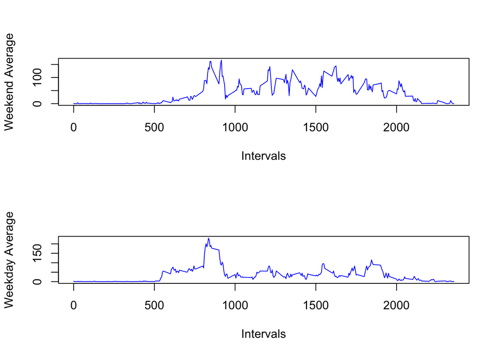

```r
par(mfrow=c(2,1))

plot(g,wknd_avg,type="l", col="blue",xlab="Intervals", ylab="Weekend Average")
plot(g,wkdy_avg,type="l", col="blue", xlab="Intervals", ylab="Weekday Average")
```